# Perkovic-Likes-Report

### 9-12-2024

1. The source of my personal Instagram data comes from Instagram themselves, as well as the my use of Instagram and the interactions I have made on Instagram.
2. This data was created for advertising and marketing for companies as well as other statistical reasons for Instagram's use. This data can serve the purpose of targeting advertising as well as looking at different types of data.
3. This data is reliable since Instagram, as well as many other comapnies, provide a data policy so users know what they are collecting, using, etc: https://help.instagram.com/155833707900388
4. This data may be unreliable if a third party were to breach a data system, or if users were to publish data to third party sites such as GitHub.

```python
import json
import pandas as pd
# importing json and pandas, shortening pandas to pd
```

```python
path = "/Users/kaitlynperkovic/Desktop/data_emat_fa24/liked_posts.json"
with open(path) as j:
    liked = json.load(j)
# opening and loading the liked_post.json file from my personal foler and giving it the variable "liked"
```

```python
liked.keys() # gives dictionary keys/terms
```

```
dict_keys(['likes_media_likes'])
```

```python
type(liked['likes_media_likes']) # what type is the term likes_media_likes
```

```
list
```

```python
liked['likes_media_likes'][2] # gives me the third most thing i liked
```

```
{'title': 'meevin_official',
 'string_list_data': [{'href': 'https://www.instagram.com/p/C-ixzqfvOdn/',
   'value': 'ð\x9f\x91\x8d',
   'timestamp': 1724376795}]}
```

```python
liked_df = pd.DataFrame(liked['likes_media_likes'])
liked_df.head()
# sorts data into a list
```

|  | title | string_list_data |
| --- | --- | --- |
| 0 | valorantesportsna | [{'href': 'https://www.instagram.com/p/C_CMfqg... |
| 1 | sentinels | [{'href': 'https://www.instagram.com/p/C_BzBaV... |
| 2 | meevin_official | [{'href': 'https://www.instagram.com/p/C-ixzqf... |
| 3 | bigbrothercbs | [{'href': 'https://www.instagram.com/p/C-8y8Ye... |
| 4 | fab_ksu | [{'href': 'https://www.instagram.com/p/C-2r0Mp... |

```python
liked_df.head(15) #the first 15 of list
```

|  | title | string_list_data |
| --- | --- | --- |
| 0 | valorantesportsna | [{'href': 'https://www.instagram.com/p/C_CMfqg... |
| 1 | sentinels | [{'href': 'https://www.instagram.com/p/C_BzBaV... |
| 2 | meevin_official | [{'href': 'https://www.instagram.com/p/C-ixzqf... |
| 3 | bigbrothercbs | [{'href': 'https://www.instagram.com/p/C-8y8Ye... |
| 4 | fab_ksu | [{'href': 'https://www.instagram.com/p/C-2r0Mp... |
| 5 | barstoolkent | [{'href': 'https://www.instagram.com/p/C-yqogA... |
| 6 | barstoolkent | [{'href': 'https://www.instagram.com/p/C-k3eK1... |
| 7 | romy.andmichelle | [{'href': 'https://www.instagram.com/p/C-nFD2b... |
| 8 | ericdoa | [{'href': 'https://www.instagram.com/reel/C-n8... |
| 9 | 60000isk | [{'href': 'https://www.instagram.com/p/C-qKzdl... |
| 10 | moist456 | [{'href': 'https://www.instagram.com/p/C-dzml_... |
| 11 | kittykittyivy | [{'href': 'https://www.instagram.com/p/C-lyIjo... |
| 12 | bandos_democracy | [{'href': 'https://www.instagram.com/p/C-ohxGi... |
| 13 | nichole__amber | [{'href': 'https://www.instagram.com/p/C-oZj4i... |
| 14 | teacherman91 | [{'href': 'https://www.instagram.com/p/C-bkxf2... |

```python
liked_df_tidy = liked_df.groupby('title').count().\
sort_values('string_list_data', ascending = False)
#groups it by user
```

```python
# liked_df_tidy
```

A hypothesis that could be tested using personal social media data is the date and time someone commented on a social media post such as on TikTok. A theoretical element of this hypothesis would be to check my activity or comment sectioin to give me the date they commented. A statistical element would be to check the data to give the exact time (hour, minute, second) and exact date they commented.

```python
import matplotlib as plt #loads matplotlib
```

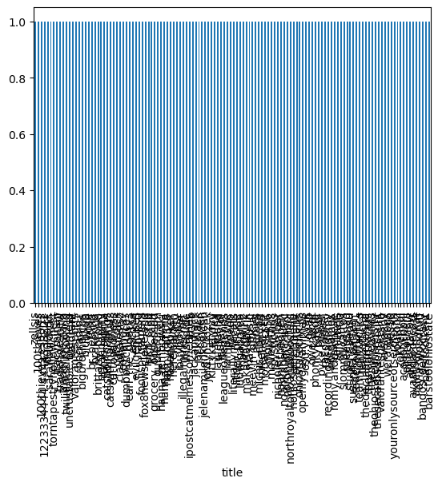

```python
liked_df_tidy.groupby('title').count().\
sort_values('string_list_data', ascending = False)['string_list_data'].plot(kind = 'bar') #creates bar graph, im unsure how to "space out" this graph
```

```python
path = "/Users/kaitlynperkovic/Desktop/data_emat_fa24/user_data_tiktok.json"
with open(path) as j:
    user = json.load(j)
#opens tiktok file
```

```python
user.keys() #defines keys
```

```
dict_keys(['Activity', 'Ads and data', 'App Settings', 'Comment', 'Direct Messages', 'Income Plus Wallet Transactions', 'Poi Review', 'Profile', 'Tiktok Live', 'Tiktok Shopping', 'Video'])
```

```python
type(user['Activity']) #what type activity is
```

```
dict
```

```python
# user['Activity'] #shows activity
```

```python
user_df = pd.DataFrame(user['Activity'])
user_df.head()
```

|  | Favorite Effects | Favorite Hashtags | Favorite Sounds | Favorite Videos | Follower List | Following List | Hashtag | Like List | Login History | Purchase History | Search History | Share History | Status | Video Browsing History |
| --- | --- | --- | --- | --- | --- | --- | --- | --- | --- | --- | --- | --- | --- | --- |
| FavoriteEffectsList | NaN | NaN | NaN | NaN | NaN | NaN | NaN | NaN | NaN | NaN | NaN | NaN | NaN | NaN |
| FavoriteHashtagList | NaN | NaN | NaN | NaN | NaN | NaN | NaN | NaN | NaN | NaN | NaN | NaN | NaN | NaN |
| FavoriteSoundList | NaN | NaN | [{'Date': '2024-08-18 05:54:15', 'Link': 'http... | NaN | NaN | NaN | NaN | NaN | NaN | NaN | NaN | NaN | NaN | NaN |
| App | NaN | NaN | NaN | 1.0 | 1 | 1 | NaN | 1 | NaN | NaN | NaN | NaN | NaN | NaN |
| FavoriteVideoList | NaN | NaN | NaN | NaN | NaN | NaN | NaN | NaN | NaN | NaN | NaN | NaN | NaN | NaN |

```python
user_df.head(10)
```

|  | Favorite Effects | Favorite Hashtags | Favorite Sounds | Favorite Videos | Follower List | Following List | Hashtag | Like List | Login History | Purchase History | Search History | Share History | Status | Video Browsing History |
| --- | --- | --- | --- | --- | --- | --- | --- | --- | --- | --- | --- | --- | --- | --- |
| FavoriteEffectsList | NaN | NaN | NaN | NaN | NaN | NaN | NaN | NaN | NaN | NaN | NaN | NaN | NaN | NaN |
| FavoriteHashtagList | NaN | NaN | NaN | NaN | NaN | NaN | NaN | NaN | NaN | NaN | NaN | NaN | NaN | NaN |
| FavoriteSoundList | NaN | NaN | [{'Date': '2024-08-18 05:54:15', 'Link': 'http... | NaN | NaN | NaN | NaN | NaN | NaN | NaN | NaN | NaN | NaN | NaN |
| App | NaN | NaN | NaN | 1.0 | 1 | 1 | NaN | 1 | NaN | NaN | NaN | NaN | NaN | NaN |
| FavoriteVideoList | NaN | NaN | NaN | NaN | NaN | NaN | NaN | NaN | NaN | NaN | NaN | NaN | NaN | NaN |
| IsFastLane | NaN | NaN | NaN | NaN | False | False | NaN | NaN | NaN | NaN | NaN | NaN | NaN | NaN |
| FansList | NaN | NaN | NaN | NaN | [{'Date': '2024-08-26 00:44:52', 'UserName': '... | NaN | NaN | NaN | NaN | NaN | NaN | NaN | NaN | NaN |
| Following | NaN | NaN | NaN | NaN | NaN | [{'Date': '2024-05-15 05:02:18', 'UserName': '... | NaN | NaN | NaN | NaN | NaN | NaN | NaN | NaN |
| HashtagList | NaN | NaN | NaN | NaN | NaN | NaN | [{'HashtagName': 'frankocean', 'HashtagLink': ... | NaN | NaN | NaN | NaN | NaN | NaN | NaN |
| ItemFavoriteList | NaN | NaN | NaN | NaN | NaN | NaN | NaN | [{'Date': '2024-08-05 03:16:28', 'Link': 'http... | NaN | NaN | NaN | NaN | NaN | NaN |

The data in the data frame list shows multiple elements that include lists of favorites, though I am unsure if there is a reason why most elements are not a number. I think that the sections, such as the following row and following list column will list who followed me at what time and day.